# Environmental parameters

Setup!

```r
data.dir <- "data"    # input data files
functions.dir <- "R"  # functions & scripts
save.dir <- "output"  # clean data, output from models & more complex calculations
figures.dir <- "figs" # plots & figures
```

```r
library(tidyverse) # data manipulation, cleaning, aggregation
```

```r
library(sjPlot) # exporting publication-quality tables to .doc files, etc.
library(mice) # explore missing values
```

Environmental parameters were measured in parallel with the zoobenthic sampling during the study:  
* water column nutrients, chl-a, suspended matter  
* water clarity (Secchi depth)  
* O2 concentrations (profiles every 1 m to the bottom - but only occasionally)  
* sediment parameters - grain size & distribution, total organic matter content, heavy metals (again only occasionally).  
Since (most) stations were selected because there were previous monitoring stations at the same/nearby locations, there is fairly long-term data on nutrient concentrations, chl-a, suspended matter, water clarity at least. This is a good thing, because opportunistic samplings of these parameters, which vary strongly even daily, and very much so seasonally, cannot reveal the real patterns (e.g. higher eutrophication levels at some stations, such as those hypothesized here for the inner Burgas Bay stations).  
Therefore, the long-term data will be used in the analyses wherever possible (and available), to try to determine the effects of this pressure on the macrobenthic communities.

```r
envir.params <- as_tibble(read.csv(file.path(data.dir, "water_column_LT_all.csv"), header = TRUE, stringsAsFactors = FALSE, na.strings = ""))
# quick sanity check (variable types, import errors, etc.)
envir.params
```

| station | month | year | depth | chl.a | Ninorg | NH4 | NO3 | Ntotal | PO4 | seston | secchi |
| --- | --- | --- | --- | --- | --- | --- | --- | --- | --- | --- | --- |
| Kraimorie | 7 | 2009 | 0 | 0.000 | 1.031 | 0.500 | 0.500 | 0.000 | 0.149 | 1.800 | 3.00 |
| Kraimorie | 7 | 2009 | 3 | 2.149 | 0.949 | 0.500 | 0.432 | 4.778 | 0.149 | 1.140 | 3.00 |
| Kraimorie | 7 | 2009 | 9 | 0.000 | 1.226 | 0.750 | 0.445 | 4.436 | 0.149 | 1.500 | 3.00 |
| Kraimorie | 8 | 2009 | 0 | 0.000 | 1.316 | 0.500 | 0.764 | 9.747 | 0.164 | 0.460 | 1.50 |
| Kraimorie | 8 | 2009 | 3 | 2.815 | 1.439 | 0.450 | 0.936 | 14.030 | 0.179 | 1.280 | 1.50 |
| Kraimorie | 8 | 2009 | 9 | 0.000 | 1.316 | 0.450 | 0.814 | 15.359 | 0.179 | 2.960 | 1.50 |
| Kraimorie | 9 | 2009 | 0 | 5.797 | 1.948 | 0.850 | 1.036 | 19.383 | 0.239 | 4.200 | 1.50 |
| Kraimorie | 9 | 2009 | 3 | 3.191 | 2.007 | 0.850 | 1.091 | 14.333 | 0.239 | 8.220 | 1.50 |
| Kraimorie | 9 | 2009 | 9 | 5.830 | 1.953 | 0.900 | 0.995 | 14.606 | 0.254 | 3.980 | 1.50 |
| Kraimorie | 10 | 2009 | 0 | 1.230 | 1.035 | 0.400 | 0.586 | 17.680 | 0.149 | 0.900 | 3.00 |

[output cut: 746 more lines]

Looks fine.

Let’s clean it up a bit..  
To have more data for my stations, I’ll add the data from some other nearby stations in Burgas Bay (and Sozopol Bay): Atia -> Akin; Maslen nos -> Paraskeva.

```r
# envir.params <- envir.params %>%
#   mutate(station = replace(station, station == "Atia", "Akin"),
#          station = replace(station, station == "Maslen nos", "Paraskeva"))
## fugly... repeated code - find a better way to formulate this!
envir.params <- envir.params %>%
  mutate(station = recode(station, "Atia" = "Akin", "Maslen nos" = "Paraskeva"))
```

#### Explore the pattern(s) of the missing data

##### Missing data in the water column parameters

```r
### check the distribution of NAs in the water column parameters
## first, for the whole dataset (long-term, as it may be)
as_tibble(mice::md.pattern(envir.params))
```

```
NAs introduced by coercion
```

| month | year | Ninorg | NO3 | NH4 | Ntotal | PO4 | depth | seston | chl.a | secchi | station |  |
| --- | --- | --- | --- | --- | --- | --- | --- | --- | --- | --- | --- | --- |
| 1 | 1 | 1 | 1 | 1 | 1 | 1 | 1 | 1 | 1 | 1 | 0 | 1 |
| 1 | 1 | 1 | 1 | 1 | 1 | 1 | 1 | 1 | 0 | 1 | 0 | 2 |
| 1 | 1 | 1 | 1 | 0 | 1 | 1 | 1 | 1 | 1 | 1 | 0 | 2 |
| 1 | 1 | 1 | 1 | 1 | 0 | 1 | 1 | 1 | 1 | 1 | 0 | 2 |
| 1 | 1 | 1 | 1 | 1 | 1 | 0 | 1 | 1 | 1 | 1 | 0 | 2 |
| 1 | 1 | 1 | 1 | 1 | 1 | 1 | 1 | 1 | 1 | 0 | 0 | 2 |
| 1 | 1 | 1 | 1 | 1 | 1 | 0 | 1 | 1 | 0 | 1 | 0 | 3 |
| 1 | 1 | 1 | 1 | 1 | 1 | 1 | 0 | 0 | 1 | 0 | 0 | 4 |
| 0 | 0 | 0 | 0 | 3 | 3 | 3 | 6 | 6 | 8 | 53 | 756 | 838 |

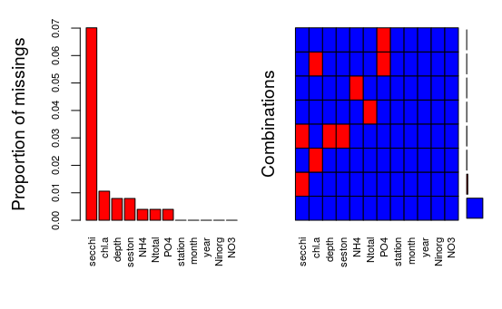

```r
## a more visual way of displaying the same NAs (package VIM)
VIM::aggr(envir.params,
          col = c("blue", "red"),
          numbers = TRUE,
          sortVars = TRUE,
          labels = names(envir.params),
          cex.axis = 0.7, gap = 3)
```

There are some; mostly for the Secchi depth, which wasn’t systematically measured.

We’ll do the same for the missing values only during the study period (2012-2014).

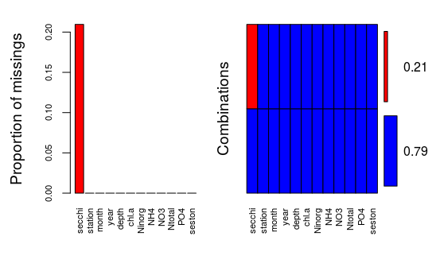

```r
envir.params %>%
  filter(year == 2012 | year == 2013 | year == 2014) %>%
  VIM::aggr(col = c("blue", "red"),
          numbers = TRUE,
          sortVars = TRUE,
          labels = names(envir.params),
          cex.axis = 0.7, gap = 3)
```

Looks like the Secchi depth is the major offender here, too, but all other water column parameters are complete.

#### Summarise the environmental data

##### Water column parameters (long-term)

Aggregate the long-term data by station, month and year (= mean).

```r
## summary by station, year and month (-> over the different depths)
envir.params.summary <- envir.params %>%
  group_by(station, year, month) %>%
  select(-(year:depth)) %>%
  summarise_all(funs(mean, sd, min, max), na.rm = TRUE)
```

Another level of aggregation: long-term averages (such as they are), by station. This will then be exported as a table, formatted from within R, to be included in the relevant thesis appendix.

```r
sjt.df(envir.params.summary.by.st,
       describe = FALSE,
       altr.row.col = TRUE,
       show.rownames = FALSE)
```

[output not shown]